# Minerva Analysis

Statistical analysis of bahavioural data from the Minerva project.

true  
2025-03-13

## Preface

The data that we’ll be using for the analysis is the cleaned version of the data. It does not include baselines, the verbs with low accuracy and outliers. Those can be found in the main repo. I’m doing this too keep the size of the data manageable as the minerva simulation data is too large and will take too long to run.

## Behavioral Data

This data has been collected by means of an acceptability judgment task. Participants were asked to judge the acceptability of a verb-noun combination by pressing the y or n key. We are interested in the reaction times (RT) and the accuracy of the responses.

The experiment had three conditions: Compositional, Collocation, Idiom. We expect RTs to be different across conditions.

**Idioms are fastest, compositional in the middle, collocations are slowest**

We do no expect accuracy to be different across conditions as these are adult L1 speakers of English and the items are somewhat frequency matched.

### Reaction Times

```r
# Group by condition and calculate the mean and standard deviation
correct <- human %>% filter(Accuracy == 1)
RT <- describeBy(correct$RT, group = correct$Condition, mat = TRUE) %>%
  as.data.frame() %>%
  rename(Condition = group1,
         Mean = mean,
         SD = sd,
         Median = median,
         Min = min,
         Max = max,
         Skewness = skew,
         Kurtosis = kurtosis) %>%
  select(Condition, Mean, SD, Median, Min, Max, Skewness, Kurtosis)
  rownames(RT) <- NULL

kable(RT, caption = "Descriptive Statistics for Reaction Times by Condition")
```

Table 1: Descriptive Statistics for Reaction Times by Condition

| Condition | Mean | SD | Median | Min | Max | Skewness | Kurtosis |
| --- | --- | --- | --- | --- | --- | --- | --- |
| Compositional | 996 | 376 | 897 | 460 | 3042 | 1.96 | 5.21 |
| Collocation | 1010 | 373 | 910 | 452 | 3058 | 1.94 | 5.07 |
| Idiom | 986 | 367 | 887 | 457 | 3031 | 1.97 | 5.05 |

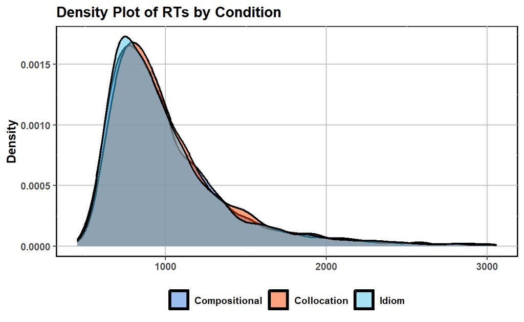

```r
human %>%
  ggplot(aes(x = RT, fill = Condition)) +
  geom_density(alpha = 0.5, linewidth = 0.8) +
  plot_theme + labs(title = "Density Plot of RTs by Condition", x = "Reaction Time (ms)", y = "Density")
```

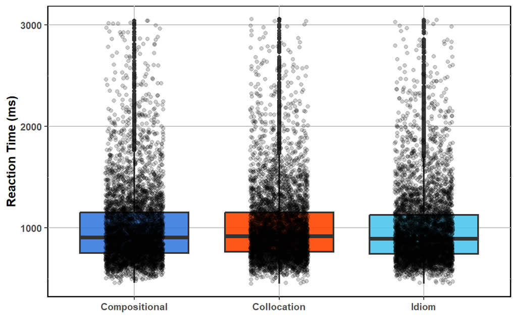

Figure 1: Boxplot of RTs by Condition

```r
# boxplot of RTs by condition
human %>%
  ggplot(aes(x = Condition, y = RT, fill = Condition)) +
  geom_boxplot(alpha = 0.9, linewidth = 0.8) +
  geom_jitter(width = 0.2, height = 0, alpha = 0.2) +
    stat_summary(fun.y=mean, geom="point", shape=2, size=2, color="black") +
  plot_theme +
  labs(x = "Condition", y = "Reaction Time (ms)") +
  theme(legend.position = "none")
```

### Accuracy

```r
# Group by condition and calculate the mean and standard deviation

Accuracy <- describeBy(human$Accuracy, group = human$Condition, mat = TRUE) %>%
  as.data.frame() %>%
  rename(Condition = group1,
         Mean = mean,
         SD = sd,
         Median = median,
         Min = min,
         Max = max,
         Skewness = skew,
         Kurtosis = kurtosis) %>%
  select(Condition, Mean, SD, Median, Min, Max, Skewness, Kurtosis)
  rownames(Accuracy) <- NULL
kable(Accuracy, caption = "Descriptive Statistics for Accuracy by Condition")
```

Table 2: Descriptive Statistics for Accuracy by Condition

| Condition | Mean | SD | Median | Min | Max | Skewness | Kurtosis |
| --- | --- | --- | --- | --- | --- | --- | --- |
| Compositional | 0.924 | 0.265 | 1 | 0 | 1 | -3.19 | 8.19 |
| Collocation | 0.938 | 0.240 | 1 | 0 | 1 | -3.65 | 11.31 |
| Idiom | 0.931 | 0.253 | 1 | 0 | 1 | -3.41 | 9.64 |

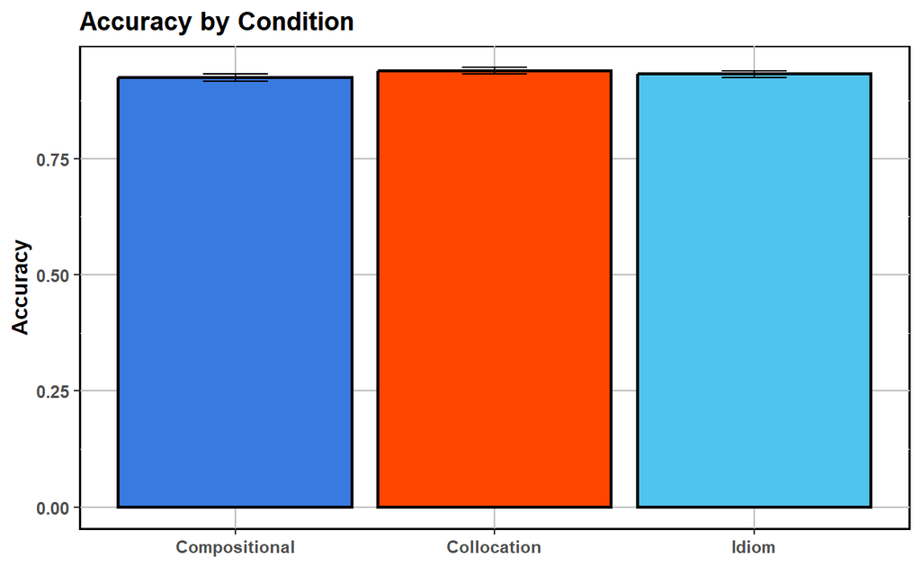

```r
# barplot of mean accuracy by condition
human %>% ggplot(aes(x = Condition, y = Accuracy, fill = Condition)) +
  geom_bar(stat = "summary", fun = "mean", position = "dodge", color = "black", linewidth = 0.8) +
  geom_errorbar(stat = "summary", fun.data = "mean_cl_normal", position = position_dodge(width = 0.9), width = 0.25) +
  plot_theme +
  labs(title = "Accuracy by Condition", x = "Condition", y = "Accuracy") + theme(legend.position = "none")
```

### Frequency

#### Condition-wise Descriptive Statistics for Frequency

```r
# Group by condition and calculate the mean and standard deviation

Frequency <- describeBy(human$Frequency, group = human$Condition, mat = TRUE) %>%
  as.data.frame() %>%
  rename(Condition = group1,
         Mean = mean,
         SD = sd,
         Median = median,
         Min = min,
         Max = max,
         Skewness = skew,
         Kurtosis = kurtosis) %>%
  select(Condition, Mean, SD, Median, Min, Max, Skewness, Kurtosis)
  rownames(Frequency) <- NULL
kable(Frequency, caption = "Descriptive Statistics for Frequency by Condition")
```

Table 3: Descriptive Statistics for Frequency by Condition

| Condition | Mean | SD | Median | Min | Max | Skewness | Kurtosis |
| --- | --- | --- | --- | --- | --- | --- | --- |
| Compositional | 18932 | 30401 | 7730 | 681 | 168395 | 2.95 | 9.34 |
| Collocation | 21413 | 31015 | 9233 | 447 | 168326 | 2.67 | 7.82 |
| Idiom | 28882 | 47760 | 11204 | 413 | 278026 | 3.03 | 10.22 |

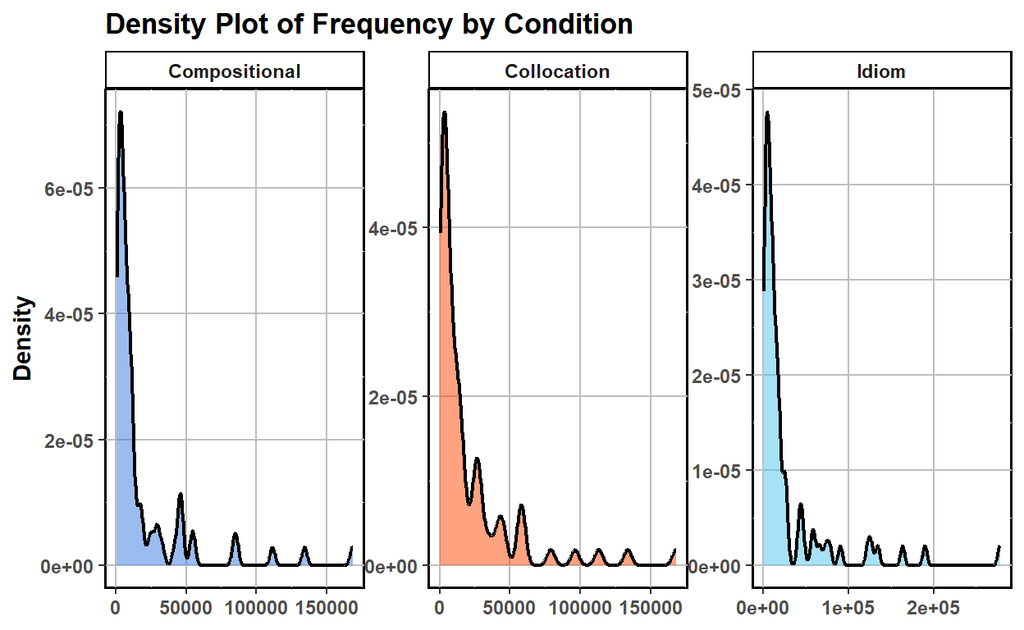

```r
# density plot of frequency by condition
human %>% ggplot(aes(x = Frequency, fill = Condition)) +
  geom_density(alpha = 0.5, linewidth = 0.8) +
  plot_theme + labs(title = "Density Plot of Frequency by Condition", x = "Frequency", y = "Density") + facet_wrap(~Condition, scales = "free") + theme(legend.position = "none")
```

#### Correlation between RT and Frequency

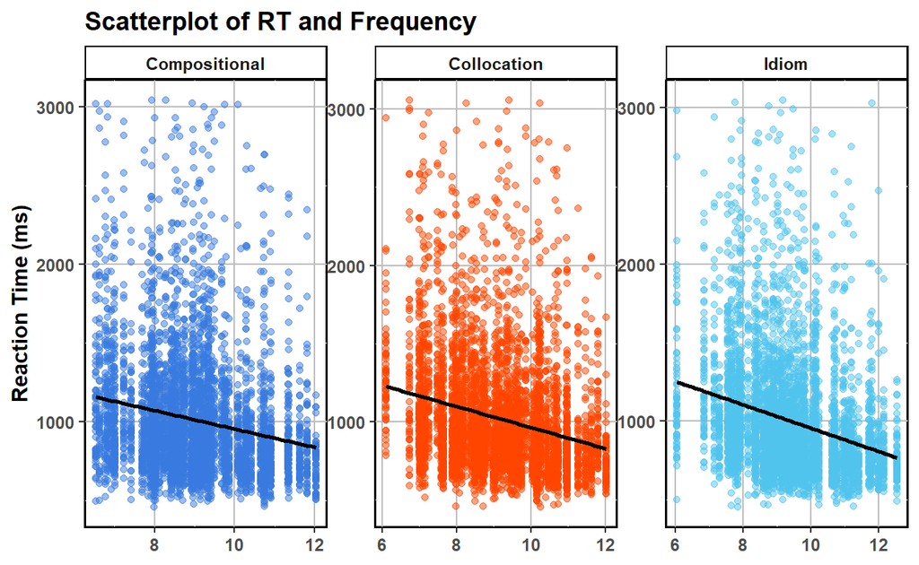

```r
# Scatterplot of RT and Frequency
human %>% ggplot(aes(x = log(Frequency), y = RT, color = Condition)) +
  geom_point(alpha = 0.5) +
  geom_smooth(method = "lm", se = FALSE, color = "black",linewidth = 1) +
   plot_theme + theme(legend.position = "none") + theme(axis.text.x = element_text()) +
  labs(title = "Scatterplot of RT and Frequency", x = "log(Frequency)", y = "Reaction Time (ms)") + facet_wrap(~Condition, scales = "free") +
  scale_color_manual(values = palette)
```

## Statistical Analysis

```r
# Fit the model

# human_model <- glmer(RT ~ Condition + scale(Frequency) + (1|ID) + (1|Verb), data = human %>% filter(Accuracy == 1), family = Gamma(link = "identity"))
```

### anova

```r
hfreq <- human %>% filter(Frequency > 28000)

hfreq %>% group_by(Condition) %>% summarise(Mean = mean(RT), SD = sd(RT), Median = median(RT), Min = min(RT), Max = max(RT)) %>%
  kable(caption = "Descriptive Statistics for High Frequency Items by Condition")
```

Table 4: Descriptive Statistics for High Frequency Items by Condition

| Condition | Mean | SD | Median | Min | Max |
| --- | --- | --- | --- | --- | --- |
| Compositional | 890 | 343 | 804 | 460 | 2752 |
| Collocation | 918 | 339 | 828 | 452 | 3040 |
| Idiom | 874 | 322 | 778 | 457 | 3031 |

```r
# anova for high frequency

aov(RT ~ Condition + log(Frequency) + Error(ID/Verb), data = hfreq %>% filter(Accuracy == 1)) %>%
summary()
```

```
##
## Error: ID
##                 Df   Sum Sq Mean Sq F value Pr(>F)
## Condition        2   514107  257053    0.62   0.54
## log(Frequency)   1    95820   95820    0.23   0.63
## Residuals      182 75719551  416041
##
## Error: ID:Verb
##                  Df   Sum Sq Mean Sq F value  Pr(>F)
## Condition         2 9.33e+05  466371    5.51  0.0041 **
## log(Frequency)    1 4.26e+06 4255670   50.26 1.7e-12 ***
## Residuals      2695 2.28e+08   84669
## ---
## Signif. codes:
## 0 '***' 0.001 '**' 0.01 '*' 0.05 '.' 0.1 ' ' 1
```